# Exercises: 05-25-20

Shawn Santo

# Packages

```r
library(tidyverse)
```

# Data

## MLB

```r
teams <- read_csv("http://www2.stat.duke.edu/~sms185/data/mlb/teams.csv")
```

Object `teams` is a data frame that contains yearly statistics and standings for MLB teams from 2009 to 2018.

The data has 300 rows and 56 variables.

## Energy

```r
energy <- read_csv("http://www2.stat.duke.edu/~sms185/data/energy/energy.csv")
```

The power sources represent the amount of energy a power source generates each day as represented in daily MWh.

- `MWhperDay`: MWh of energy generated per day
- `name`: energy source name
- `type`: type of energy source
- `location`: country of energy source
- `note`: more details on energy source
- `boe`: barrel of oil equivalent
- **Daily megawatt hour (MWh)** is a measure of energy output.
- **1 MWh** is, on average, enough power for 28 people in the USA

## Flint water

```r
flint <- read_csv("http://www2.stat.duke.edu/~sms185/data/health/flint.csv")
```

Each row represents a home in Flint, Michigan. Water lead contaminant value were recorded at three times as represented by `draw1`, `draw2`, and `draw3`.

# Exercise 1

## Problem

Use tibble `teams` to re-create the plot below.

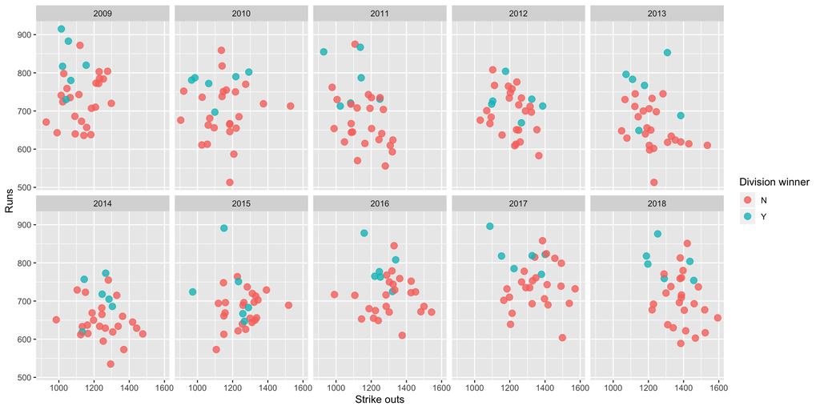

## Solution

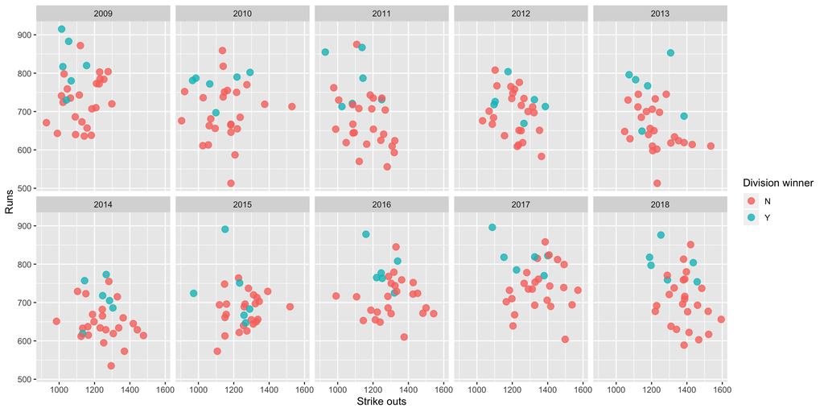

```r
ggplot(data = teams, mapping = aes(x = SO, y = R, color = factor(DivWin))) +
  geom_point(size = 3, alpha = .8) +
  facet_wrap(~yearID, nrow = 2) +
  labs(x = "Strike outs", y = "Runs", color = "Division winner")
```

# Exercise 2

## Problem

Try to improve the visualization in Exercise 1 by drawing attention to the division winners and their relationship between runs and strikeouts.

## Solution

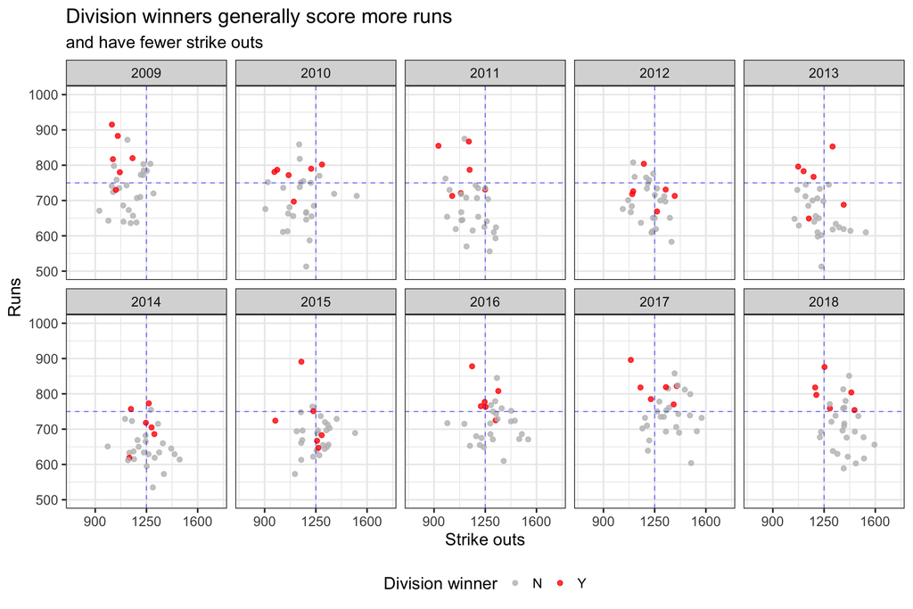

```r
ggplot(data = teams, mapping = aes(x = SO, y = R, color = factor(DivWin))) +
  geom_point(size = 2, alpha = .8) +
  geom_hline(yintercept = 750, lty = 2, alpha = .5, color = "blue") +
  geom_vline(xintercept = 1250, lty = 2, alpha = .5, color = "blue") +
  facet_wrap(~yearID, nrow = 2) +
  labs(x = "Strike outs", y = "Runs", color = "Division winner",
       title = "Division winners generally score more runs",
       subtitle = "and have fewer strike outs") +
  scale_color_manual(values = c("grey", "red")) +
  scale_x_continuous(limits = c(750, 1750), breaks = seq(900, 1700, 350),
                     labels = seq(900, 1700, 350)) +
  scale_y_continuous(limits = c(500, 1000), breaks = seq(500, 1000, 100),
                     labels = seq(500, 1000, 100)) +
  theme_bw(base_size = 16) +
  theme(legend.position = "bottom")
```

# Exercise 3

## Problem

Re-create the plot below using `energy`.

A few notes:

- base font size is 18
- hex colors: `c("#9d8b7e", "#315a70", "#66344c", "#678b93", "#b5cfe1", "#ffcccc")`
- use function `order()` to help get the top 30

Starter code:

```r
energy_top_30 <- energy[order(energy$MWhperDay, decreasing = T)[1:30], ]
```

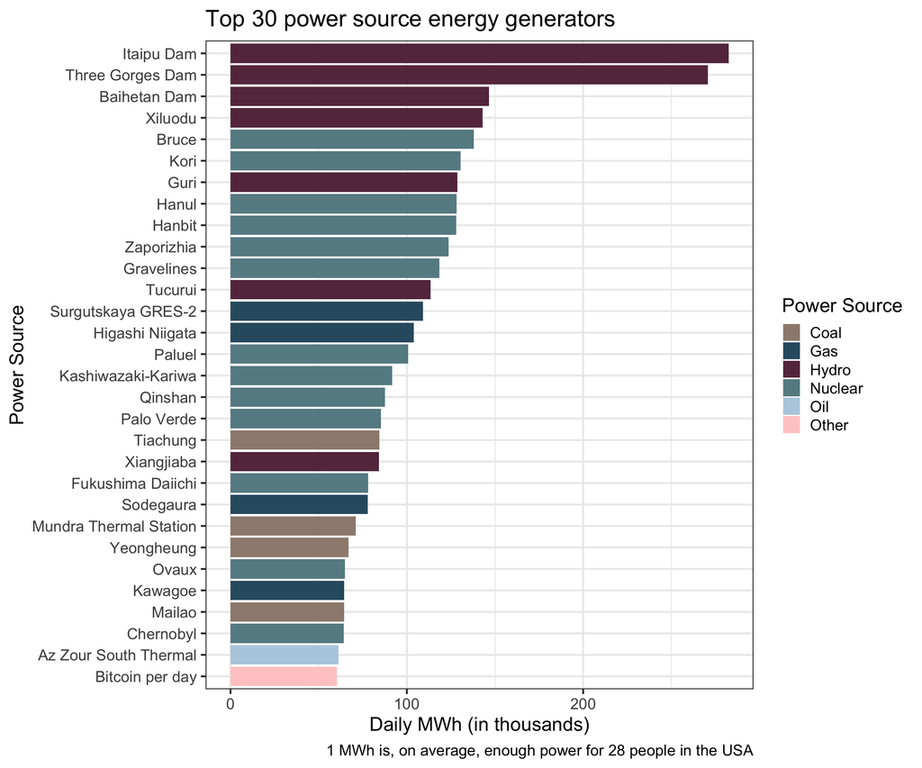

## Solution

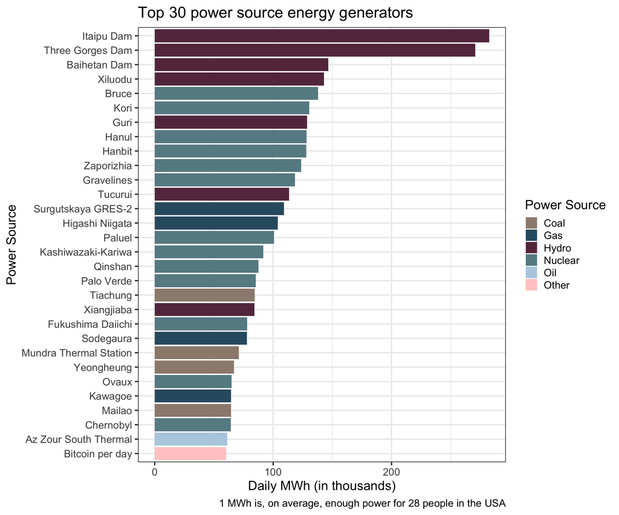

```r
ggplot(energy_top_30, mapping = aes(x = reorder(name, MWhperDay),
                                    y = MWhperDay / 1000,
                                    fill = type)) +
  geom_bar(stat = "identity") +
  scale_fill_manual(values = c("#9d8b7e", "#315a70", "#66344c",
                               "#678b93", "#b5cfe1", "#ffcccc")) +
  theme_bw(base_size = 18) +
  labs(y       = "Daily MWh (in thousands)", x = "Power Source",
       title   = "Top 30 power source energy generators",
       fill    = "Power Source",
       caption = "1 MWh is, on average, enough power for 28 people in the USA") +
  coord_flip()
```

# Exercise 4

## Problem

Recreate the plot below using `flint`.

Some details to help you replicate the plot:

- remove zip codes 48529 and 48502
- color choices: red, “#256d7b”
- font size: 16
- `theme_bw()`

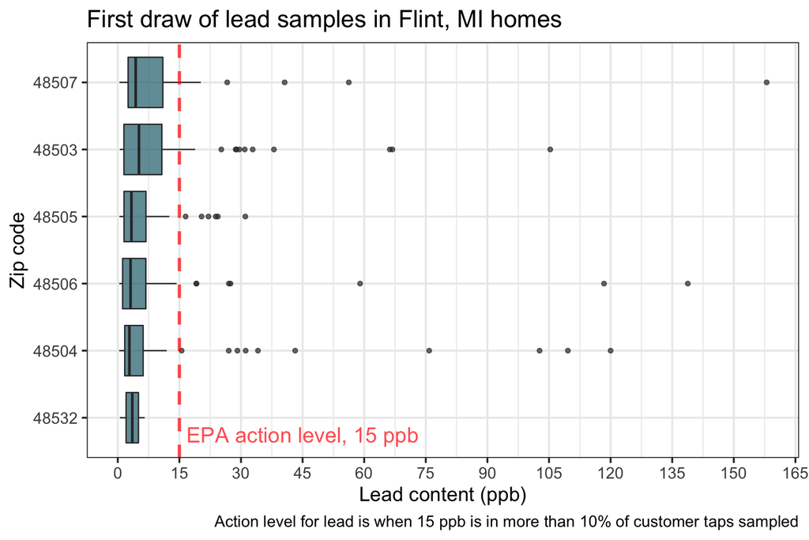

## Solution

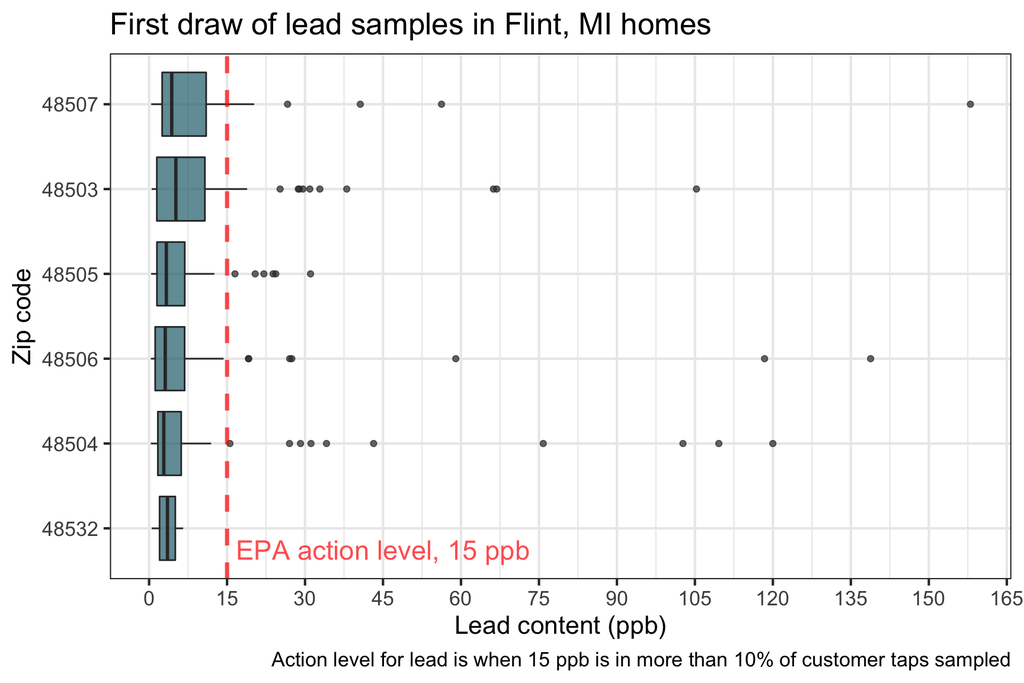

```r
flint %>%
  filter(!(zip %in% c(48529, 48502))) %>%
  ggplot(mapping = aes(x = reorder(factor(zip), draw1, quantile, .75), y = draw1)) +
  geom_boxplot(fill = "#256d7b", alpha = 0.7) +
  scale_y_continuous(breaks = seq(0, 165, 15), labels = seq(0, 165, 15)) +
  coord_flip() +
  geom_hline(yintercept = 15, color = "red", alpha = 0.7,
             linetype = 2, size = 1.25) +
  annotate("text", y = 45, x = .75, label = "EPA action level, 15 ppb",
           color = "red", alpha = 0.7, size = 6) +
  labs(x = "Zip code", y = "Lead content (ppb)",
       caption = "Action level for lead is when 15 ppb is in more than 10% of customer taps sampled", title = "First draw of lead samples in Flint, MI homes") +
  theme_bw(base_size = 16)
```